# Severe Wheather Events, 1950-2011: Effects on Human Health and Economic Consequences

Carlos Schuler

6/3/2020

## Synopsis

In this report, we explore the NOAA Storm Database (which includes data on Severe Weather Events in the United States from 1950 to 2011, including location, impact to human life, property, crops, etc.) to answer two basic questions:

1. Across the United States, which types of events are most harmful with respect to population health?
2. Across the United States, which types of events have the greatest economic consequences?

The analysis presented below shows that, overwhelmingly, *tornadoes* are most harmful to population health, while *floods*, *hurricanes/typhoons* and *tornadoes* are the top three contributors to economic losses.

## Loading and Processing the Raw Data

The data from NOAA Storm Database is downloaded from [this location](https://d396qusza40orc.cloudfront.net/repdata%2Fdata%2FStormData.csv.bz2). This database contains information regarding severe weather events in the years 1950 - 2011. Information regarding this database can be found at:  
* [National Weather Service Storm Data Documentation](https://d396qusza40orc.cloudfront.net/repdata%2Fpeer2_doc%2Fpd01016005curr.pdf)  
* [National Climatic Data Center Storm Events FAQ](https://d396qusza40orc.cloudfront.net/repdata%2Fpeer2_doc%2FNCDC%20Storm%20Events-FAQ%20Page.pdf)

### Packages and environment used in this analysis

The following libraries are used in the present analysis:

```r
library(tibble)
library(dplyr)
library(ggplot2)
library(stringr)
```

### Data Processing: Downloading and Reading the Data

The data is downloaded directly from its [web repository](https://d396qusza40orc.cloudfront.net/repdata%2Fdata%2FStormData.csv.bz2). The data is contained in a compressed, comma-delimited file, with headers in the first line.

```r
dataFileName <- "repdata-data-StormData.csv.bz2"
if(download.file("https://d396qusza40orc.cloudfront.net/repdata%2Fdata%2FStormData.csv.bz2",
              dataFileName)) stop("Error downloading file")
if(!file.exists(dataFileName)) stop("Could not find data file")

# read.csv can read compressed files
stormData<-as_tibble(read.csv(dataFileName))
```

The dimensions and structure of the data frame are:

```r
print(dimensions <- dim(stormData))
```

```
## [1] 902297     37
```

```r
str(stormData)
```

```
## tibble [902,297 × 37] (S3: tbl_df/tbl/data.frame)
##  $ STATE__   : num [1:902297] 1 1 1 1 1 1 1 1 1 1 ...
##  $ BGN_DATE  : chr [1:902297] "4/18/1950 0:00:00" "4/18/1950 0:00:00" "2/20/1951 0:00:00" "6/8/1951 0:00:00" ...
##  $ BGN_TIME  : chr [1:902297] "0130" "0145" "1600" "0900" ...
##  $ TIME_ZONE : chr [1:902297] "CST" "CST" "CST" "CST" ...
##  $ COUNTY    : num [1:902297] 97 3 57 89 43 77 9 123 125 57 ...
##  $ COUNTYNAME: chr [1:902297] "MOBILE" "BALDWIN" "FAYETTE" "MADISON" ...
##  $ STATE     : chr [1:902297] "AL" "AL" "AL" "AL" ...
##  $ EVTYPE    : chr [1:902297] "TORNADO" "TORNADO" "TORNADO" "TORNADO" ...
##  $ BGN_RANGE : num [1:902297] 0 0 0 0 0 0 0 0 0 0 ...
##  $ BGN_AZI   : chr [1:902297] "" "" "" "" ...
##  $ BGN_LOCATI: chr [1:902297] "" "" "" "" ...
##  $ END_DATE  : chr [1:902297] "" "" "" "" ...
##  $ END_TIME  : chr [1:902297] "" "" "" "" ...
##  $ COUNTY_END: num [1:902297] 0 0 0 0 0 0 0 0 0 0 ...
```

[output cut: 23 more lines]

The database contains 902297 records, each containing 37 fields of information. For the present analysis, the columns we are interested in are:

- *EVTYPE*: the type of event
- *FATALITIES*: number of fatalities associated with the event
- *INJURIES*: number of injuries associated with the event
- *PROPDMG*, *PROPDMGEXP*: estimated property damage
- *CROPDMG*, *CROPDMGEXP*: estimated crop damage

```r
# Keep only what we need
stormData <- stormData %>% select(EVTYPE,FATALITIES,INJURIES,PROPDMG,
                                  PROPDMGEXP,CROPDMG,CROPDMGEXP)
```

Inspection of EVTYPE shows inconsistent capitalization and spacing. To ensure proper grouping, this following clean-up is performed:

```r
# Cleanup EVTYPE
stormData <- stormData %>% mutate(EVTYPE = as.factor(toupper(str_squish(EVTYPE))))
```

There are other transliterations and spelling errors in the *EVTYPE* field, no efforts to correct these are made in this study.

Note that *EVTYPE* is coerced as a **factor**. The first 10 rows of the resulting data frame are:

```r
head(stormData,10)
```

```
## # A tibble: 10 x 7
##    EVTYPE  FATALITIES INJURIES PROPDMG PROPDMGEXP CROPDMG CROPDMGEXP
##    <fct>        <dbl>    <dbl>   <dbl> <chr>        <dbl> <chr>
##  1 TORNADO          0       15    25   K                0 ""
##  2 TORNADO          0        0     2.5 K                0 ""
##  3 TORNADO          0        2    25   K                0 ""
##  4 TORNADO          0        2     2.5 K                0 ""
##  5 TORNADO          0        2     2.5 K                0 ""
##  6 TORNADO          0        6     2.5 K                0 ""
##  7 TORNADO          0        1     2.5 K                0 ""
##  8 TORNADO          0        0     2.5 K                0 ""
##  9 TORNADO          1       14    25   K                0 ""
## 10 TORNADO          0        0    25   K                0 ""
```

## Results

### Effects of Severe Weather on Human Life

The question *“Which types of events are most harmful with respect to population health?”*, can be asnwered by simply adding the number of *FATALITIES* and *INJURIES*. This will provide a crude quantification of the *harm*. After grouping by event type, *EVTYPE*, the harm for each category, *catHarm* is calculated. Finally, the total harm, *totalharm* and the percentage contribution for each event type, *percentHarm*, is evaluated.

```r
# Harm to population health is captured in FATALITIES and INJURIES
sumHarmSD <- stormData %>%
        mutate(harm = FATALITIES + INJURIES) %>%                # calculate harm
        group_by(EVTYPE) %>%                                    # group events
        summarize(catHarm = sum(harm)) %>%                      # summarize harm by event
        mutate(totalHarm = sum(catHarm),                        # calculate total harm
               percentHarm = catHarm/totalHarm*100) %>%         # calculate percentages
        arrange(desc(percentHarm))                              # sort descending

head(sumHarmSD)
```

```
## # A tibble: 6 x 4
##   EVTYPE         catHarm totalHarm percentHarm
##   <fct>            <dbl>     <dbl>       <dbl>
## 1 TORNADO          96979    155673       62.3
## 2 EXCESSIVE HEAT    8428    155673        5.41
## 3 TSTM WIND         7461    155673        4.79
## 4 FLOOD             7259    155673        4.66
## 5 LIGHTNING         6046    155673        3.88
## 6 HEAT              3037    155673        1.95
```

A total of 155.67 thousand *CASUALTIES* and *INJURIES* are recorded in the database, caused by severe weather events. Of these, *TORNADO* as a category clearly dominates as the principal cause of harm to health in the period 1950-2011. Below, *TORNADO* events are “separated out” so that this event category does not overwhelm the graphical representation of other event categories.

```r
topHarmSD <- sumHarmSD %>% slice(n=1)                           # select top 1
# Create "Other" row
otherTotalHarm = topHarmSD$totalHarm[1]
otherCatHarm = otherTotalHarm - sum(topHarmSD$catHarm)
otherPercentHarm = 100 - sum(topHarmSD$percentHarm)

topHarmSD <- topHarmSD %>%
        add_row(EVTYPE="All Other Events",
                catHarm=otherCatHarm,
                totalHarm=otherTotalHarm,
                percentHarm=otherPercentHarm)
topHarmSD
```

```
## # A tibble: 2 x 4
##   EVTYPE           catHarm totalHarm percentHarm
##   <chr>              <dbl>     <dbl>       <dbl>
## 1 TORNADO            96979    155673        62.3
## 2 All Other Events   58694    155673        37.7
```

The next 10 event categories are prepared for graphical display:

```r
# Events excluding top contributor
highHarmSD <- sumHarmSD %>% slice(n=2:11)                       # select next top 10
highHarmSD$EVTYPE <- factor(highHarmSD$EVTYPE,
                               levels = highHarmSD$EVTYPE)      # sort labels
```

In the figure below, the panel on the left shows how *TORNADO* contribute 62% to the total number of *CASUALTIES* and *INJURIES*. The panel on the right shows the contributions of the next 10 event categories to the this total.

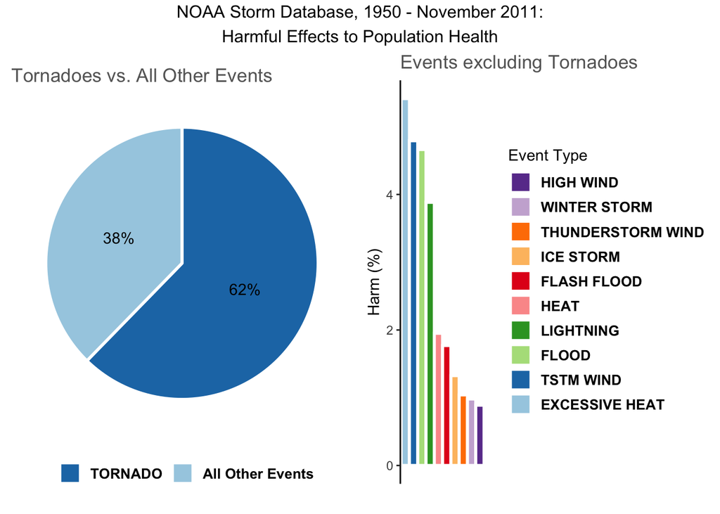

```r
# Plots
# Pie Chart top contributor
plot1 = ggplot(topHarmSD,
       aes(x="", y=percentHarm, fill=EVTYPE)) +
        geom_bar(width = 1, size = 1, color = "white", stat = "identity") +
        coord_polar("y", start=0) +
        geom_text(aes(label = paste0(round(percentHarm), "%")),
                  position = position_stack(vjust = 0.5)) +
        labs(x = NULL, y = NULL, fill = NULL,
             title = "Tornadoes vs. All Other Events") +
        guides(fill = guide_legend(reverse = TRUE)) +
        scale_fill_brewer(palette="Paired") +
        theme_classic() +
        theme(axis.line = element_blank(),
              axis.text = element_blank(),
              axis.ticks = element_blank(),
              plot.title = element_text(hjust = 0, color = "#666666"),
              legend.text = element_text(face = "bold", size = 10),
              legend.position = "bottom")
# Bar chart - 10 other contributors
plot2 = ggplot(highHarmSD,
       aes(x=EVTYPE, y=percentHarm, fill=EVTYPE)) +
        geom_bar(width = 1, size = 1, color = "white", stat = "identity") +
        labs(x = "", y = "Harm (%)", fill = "Event Type",
             title = "Events excluding Tornadoes") +
        guides(fill = guide_legend(reverse = TRUE)) +
        scale_fill_brewer(palette="Paired") +
        theme_classic() +
        theme(axis.line.x = element_blank(),
              axis.text.x = element_blank(),
              axis.ticks.x = element_blank(),
              plot.title = element_text(hjust = 0, color = "#666666"),
              legend.text = element_text(face = "bold", size = 10))
# Render both plots in one side-by-side chart
gridExtra::grid.arrange(plot1,plot2,ncol=2,
                        top = "NOAA Storm Database, 1950 - November 2011:\nHarmful Effects to Population Health")
```

The second highest contributor to harm is EXCESSIVE HEAT at 5%.

### Economic Consequences of Severe Weather Events

The question *Which types of events have the greatest economic consequences?* can be answered by tallying up crop and property damages. These are encoded in the database in the fields *CROPDMG*, *CROPDMGEXP*, *PROPDMG* and *PROPDMGEXP* in the form *base x 10^exp*, where *CROPDMG* and *PROPDMG* are *base* for crops and property, and *CROPDMGEXP* and *PROPDMGEXP* are their respective *exp*onents.

According to the documentation, the exponent in the database is coded as *K* for *thousands* (*exp*=3), *M* for *millions* (*exp*=6), etc. However, other letters and numbers populate these fields. In this study, the *EXP*onents are interpreted according to the table presented below. The numeric values, “1”, “2” … “9”, are not documented in the database description, but it appears to this analyst that this interpretation is a reasonable extrapolation.

```r
knownMult <- data.frame(exp= c("",  "H",  "h",  "K",  "k",  "M",  "m",  "B",  "b",
                               "0",  "1",  "2",  "3",  "4",  "5",  "6",  "7",  "8",
                               "9"),
             mult=as.numeric(c( 1,  100,  100,  1e3,  1e3,  1e6,  1e6,  1e9,  1e9,
                                1,   10,  100,  1e3,  1e4,  1e5,  1e6,  1e7, 1e8,
                                1e9)))

# Output as a pretty table, split in two, side-by-side
leftTab<- knitr::kable(slice(knownMult,n=1:9), "html",
                       col.names=c("*EXP*onent value", "Base multiplier"),
                       align=c("c","c")) %>%
        kableExtra::kable_styling(bootstrap_options = c("striped","hover"),
                                  full_width = F, position="float_left")

rightTab<-knitr::kable(slice(knownMult,n=10:19),"html",
                       col.names=c("*EXP*onent value", "Base multiplier"),
                       align=c("c","c")) %>%
        kableExtra::kable_styling(bootstrap_options = c("striped","hover"),
                                  full_width = F, position="right")
print(leftTab);print(rightTab)
```

| *EXP*onent value | Base multiplier |
| --- | --- |
|  | 1e+00 |
| H | 1e+02 |
| h | 1e+02 |
| K | 1e+03 |
| k | 1e+03 |
| M | 1e+06 |
| m | 1e+06 |
| B | 1e+09 |
| b | 1e+09 |

| *EXP*onent value | Base multiplier |
| --- | --- |
| 0 | 1e+00 |
| 1 | 1e+01 |
| 2 | 1e+02 |
| 3 | 1e+03 |
| 4 | 1e+04 |
| 5 | 1e+05 |
| 6 | 1e+06 |
| 7 | 1e+07 |
| 8 | 1e+08 |
| 9 | 1e+09 |

There are entries in the database with uninterpretable *EXP* values:

```r
print(unknownChars <-unique(c(stormData$PROPDMGEXP[!(stormData$PROPDMGEXP %in% knownMult$exp)],
         stormData$CROPDMGEXP[!(stormData$CROPDMGEXP %in% knownMult$exp)])))
```

```
## [1] "+" "?" "-"
```

The characters “+, ?, -” appear in the *EXP*onent fields. Fortunately, there is only a few records affected:

```r
print(unknownCount <- mean(!(stormData$CROPDMGEXP %in% knownMult$exp &
                                stormData$PROPDMGEXP %in% knownMult$exp))*100)
```

```
## [1] 0.002327393
```

Only 0.002% of the entries are uninterpretable, they will be ignored.

The economic impact calculation involves:

- Filtering the records to eliminate those that are uninterpretable
- Use *left_join* operations to translate the *EXP*onent codes to multipliers as per the table above
- Perform the “*base x multilier*” operations for both *crop damage* and *property damage*
- Add *crop* and *property damages* to obtain the total *damage* for each event
- Group the dataset by event type, *EVTYPE*
- Calculate the cummulative damage associated with each event type, *catDamage*
- Add the category damages to calculate the total damage, *totalDamage*
- Calculate the relative contribution from each category, *percentDamage*.

The code presented below implements these operations.

This report focuses on the top 10 contributors to *totalDamage*. This economic impact calculation ignores the contributions relating to the time-value of money, eg., one dollar in 1950 is considered equivalent to one dollar in 2011 (which is clearly not the case). However, this simple calculation will allow to present a preliminary ranking of the event categories in terms of their economic impact.

```r
dmgSD <- stormData %>%
        filter(CROPDMGEXP %in% knownMult$exp,PROPDMGEXP %in% knownMult$exp) %>%
        left_join(knownMult,by=c("PROPDMGEXP"="exp")) %>%
        rename(propMult=mult) %>%                               # property multipliers
        left_join(knownMult,by=c("CROPDMGEXP"="exp")) %>%
        rename(cropMult=mult) %>%                               # crop multipliers
        mutate(damage = PROPDMG*propMult +
                       CROPDMG*cropMult) %>%                    # calculate damage
        group_by(EVTYPE) %>%                                    # group events
        summarize(catDamage = sum(damage)/10^9) %>%             # summarize impact by event in billion$
        mutate(totalDamage = sum(catDamage),                    # calculate total impact
               percentDamage = catDamage/totalDamage*100) %>%   # calculate percentages
        arrange(desc(percentDamage)) %>%                        # sort descending
        slice(n=1:10)
print(dmgSD)
```

```
## # A tibble: 10 x 4
##    EVTYPE            catDamage totalDamage percentDamage
##    <fct>                 <dbl>       <dbl>         <dbl>
##  1 FLOOD                150.          477.         31.5
##  2 HURRICANE/TYPHOON     71.9         477.         15.1
##  3 TORNADO               57.4         477.         12.0
##  4 STORM SURGE           43.3         477.          9.08
##  5 HAIL                  18.8         477.          3.93
##  6 FLASH FLOOD           18.2         477.          3.82
##  7 DROUGHT               15.0         477.          3.15
##  8 HURRICANE             14.6         477.          3.06
##  9 RIVER FLOOD           10.1         477.          2.13
## 10 ICE STORM              8.97        477.          1.88
```

Total damages are estimated at $477.3 billion. The highest losses come from FLOOD events. The figure below presents the financial impact of the top 10 events, ranked in descending order of severity.

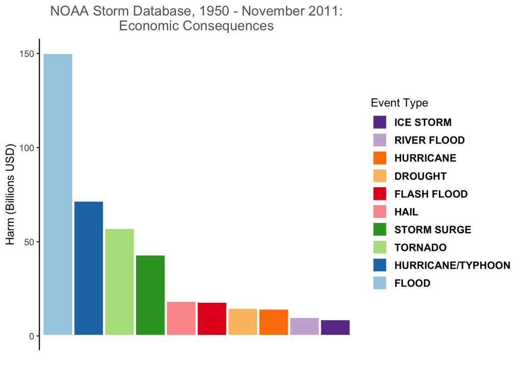

```r
dmgSD$EVTYPE <- factor(dmgSD$EVTYPE,
                            levels = dmgSD$EVTYPE)              # sort labels

ggplot(dmgSD, aes(x=EVTYPE, y=catDamage, fill=EVTYPE)) +
        geom_bar(width = 1, size = 1, color = "white", stat = "identity") +
        labs(x = "", y = "Harm (Billions USD)", fill = "Event Type",
             title = "NOAA Storm Database, 1950 - November 2011:\nEconomic Consequences") +
        guides(fill = guide_legend(reverse = TRUE)) +
        scale_fill_brewer(palette="Paired") +
        theme_classic() +
        theme(axis.line.x = element_blank(),
              axis.text.x = element_blank(),
              axis.ticks.x = element_blank(),
              plot.title = element_text(hjust = 0.5, color = "#666666"),
              legend.text = element_text(face = "bold", size = 10))
```